# Detecting assembled protein complexes in a CF-MS experiment

–

This vignette demonstrates the application of the PrInCE function `detect_complexes` to identify assembled protein complexes in CF-MS data from two different compartments: the cytosol (fractionated using size exclusion chromatography, SEC) and the mitochondria (fractionated using blue native polyacrylamide gel electrophoresis, BN-PAGE). The data is obtained from Scott et al., *Molecular Systems Biology* 2017, doi: 10.15252/msb.20167067.

First, we will load the data from Scott et al. This was obtained from the supplementary information of the original publication and pre-processed using the script in `R/preprocessing/preprocess-Scott2017.R`.

```r
chroms = readRDS("data/Scott2017/chromatograms.rds")
names(chroms)
```

```
##  [1] "SEC unstimulated 1"     "SEC stimulated 1"       "BN-PAGE unstimulated 1"
##  [4] "BN-PAGE stimulated 1"   "SEC unstimulated 2"     "SEC stimulated 2"
##  [7] "BN-PAGE unstimulated 2" "BN-PAGE stimulated 2"   "SEC unstimulated 3"
## [10] "SEC stimulated 3"       "BN-PAGE unstimulated 3" "BN-PAGE stimulated 3"
```

We will subset to analyze only the unstimulated replicates.

```r
keep = grepl("unstimulated", names(chroms))
chroms %<>% extract(keep)
names(chroms)
```

```
## [1] "SEC unstimulated 1"     "BN-PAGE unstimulated 1" "SEC unstimulated 2"
## [4] "BN-PAGE unstimulated 2" "SEC unstimulated 3"     "BN-PAGE unstimulated 3"
```

To perform this analysis, we also need a set of known protein complexes to test for the presence of. For the purpose of this analysis, we will use protein complexes from the [CORUM](http://mips.helmholtz-muenchen.de/corum/) database (Giurgiu et al., *Nucleic Acids Research* 2019, doi: 10.1093/nar/gky973), which have been preprocessed using the script at `R/preprocessing/preprocess-CORUM.R`.

```r
complexes = readRDS("data/CORUM/complexes.rds")
head(names(complexes))
```

```
## [1] "BCL6-HDAC4 complex"
## [2] "BLOC-1 (biogenesis of lysosome-related organelles complex 1)"
## [3] "SWAP complex"
## [4] "SMN containing complex"
## [5] "SMN-PolII-RHA complex"
## [6] "PPP4C-PPP4R2-Gemin3-Gemin4 complex"
```

To identify protein complexes that display a significant co-elution signature, we now need to run the `detect_complexes` function on each CF-MS chromatogram matrix. This function implements a statistical test adapted from one proposed by Tan et al. for the analysis of thermal proximity co-aggregation data (*Science* 2018, doi: 10.1126/science.aan0346). Briefly, for each protein complex with at least three subunits represented in the matrix, we calculate the median Pearson correlation between all subunits. Then, we shuffle the protein complexes 100 times and re-calculate the median Pearson correlation between all subunits for random complexes, to determine the random expectation for a protein complex with the same number of subunits.

```r
set.seed(0)
results = map(chroms, ~ detect_complexes(., complexes) %>%
                extract(!is.na(.)) %>%
                as.tibble(rownames = 'complex') %>%
                dplyr::rename(z_score = value))
str(results)
```

```
## List of 6
##  $ SEC unstimulated 1    : tibble [198 × 2] (S3: tbl_df/tbl/data.frame)
##   ..$ complex: chr [1:198] "SMN-PolII-RHA complex" "Ubiquitin E3 ligase (CDT1, DDB1, CUL4A, RBX1)" "COP9 signalosome complex" "ASF1-histone containing complex" ...
##   ..$ z_score: num [1:198] -1.43 4.99 2.67 -0.44 1.84 ...
##  $ BN-PAGE unstimulated 1: tibble [172 × 2] (S3: tbl_df/tbl/data.frame)
##   ..$ complex: chr [1:172] "SMN-PolII-RHA complex" "SMN complex" "ASF1-histone containing complex" "Cofilin-actin-CAP1 complex" ...
##   ..$ z_score: num [1:172] 0.242 3.015 0.697 -0.757 6.44 ...
##  $ SEC unstimulated 2    : tibble [294 × 2] (S3: tbl_df/tbl/data.frame)
##   ..$ complex: chr [1:294] "SMN-PolII-RHA complex" "PPP4C-PPP4R2-Gemin3-Gemin4 complex" "SMN complex" "Cohesin-SA1 complex" ...
##   ..$ z_score: num [1:294] 0.3 2.13 2.5 1.63 1.83 ...
##  $ BN-PAGE unstimulated 2: tibble [142 × 2] (S3: tbl_df/tbl/data.frame)
##   ..$ complex: chr [1:142] "SMN-PolII-RHA complex" "SMN complex" "Cofilin-actin-CAP1 complex" "Respiratory chain complex I (holoenzyme), mitochondrial" ...
##   ..$ z_score: num [1:142] 1.273 1.644 -0.203 2.584 -0.385 ...
##  $ SEC unstimulated 3    : tibble [312 × 2] (S3: tbl_df/tbl/data.frame)
##   ..$ complex: chr [1:312] "SMN-PolII-RHA complex" "PPP4C-PPP4R2-Gemin3-Gemin4 complex" "SMN complex" "Cohesin-SA1 complex" ...
##   ..$ z_score: num [1:312] -0.429 2.446 1.23 0.431 0.397 ...
##  $ BN-PAGE unstimulated 3: tibble [161 × 2] (S3: tbl_df/tbl/data.frame)
##   ..$ complex: chr [1:161] "SMN-PolII-RHA complex" "SMN complex" "COP9 signalosome complex" "ASF1-histone containing complex" ...
##   ..$ z_score: num [1:161] -0.924 2.272 -0.814 0.895 -0.452 ...
```

This returns, for each CF-MS experiment, a list of complexes with the z-score of the median intra-complex Pearson correlation relative to random complexes of equivalent size.

`detect_complexes` has several parameters that are worth briefly discussing. By default, `detect_complexes` will calculate the median correlation for 100 randomly shuffled complexes; this number can be increased or decreased using the `bootstraps` argument. Pairs of proteins in the same complex that were not detected in at least 10 overlapping fractions will not be considered, to minimize the impact of poorly-quantified subunits on the results; this number can be increased or decreased using the `min_pairs` argument The Pearson correlation is used by default as the test statistic to quantify co-elution, but this can optionally be replaced by the Euclidean distance with `method = 'euclidean'`. Last, the progress bar can be disabled by setting `progress = FALSE`.

We can obtain a visual overview of the differences plot these results as a heatmap, keeping only protein complexes with a significant elution score in at least one replicate (defined here as z $\geq$ 1.96):

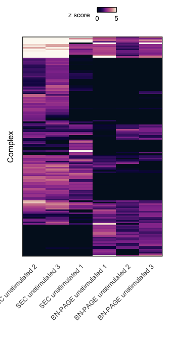

```r
# convert to tidy data frame and
df = bind_rows(results, .id = 'replicate') %>%
  group_by(complex) %>%
  filter(sum(z_score >= 1.96) > 0) %>%
  ungroup()

# convert to a matrix to cluster rows and columns
mat = df %>%
  spread(complex, z_score) %>%
  column_to_rownames('replicate') %>%
  as.matrix() %>%
  # replace missing values with zeroes
  replace_na(0)
clust_complexes = hclust(dist(t(mat)))
clust_replicates = hclust(dist(mat))
complex_levels = with(clust_complexes, labels[order])
replicate_levels = with(clust_replicates, labels[order])

# finally, plot the heatmap
pal = jdb_palette("china_sunset") %>% colorRampPalette() %>% do.call(list(100))
p = mat %>%
  reshape2::melt(varnames = c('replicate', 'complex'), value.name = 'z_score',
                 as.is = TRUE) %>%
  mutate(complex = factor(complex, levels = complex_levels),
         replicate = factor(replicate, levels = replicate_levels),
         # cap z-scores at 5
         z_score = winsorize(z_score, c(0, 5))) %>%
  ggplot(aes(x = replicate, y = complex, fill = z_score)) +
  geom_tile() +
  scale_y_discrete('Complex', expand = c(0, 0)) +
  scale_x_discrete('', expand = c(0, 0)) +
  scale_fill_gradientn(colours = pal, breaks = c(0, 5)) +
  guides(fill = guide_colorbar("z score  ", frame.colour = "black", ticks = F)) +
  boxed_theme(size_sm = 5, size_lg = 6) +
  theme(axis.text.y = element_blank(),
        axis.ticks.y = element_blank(),
        axis.text.x = element_text(angle = 45, hjust = 1),
        axis.ticks.x = element_blank(),
        legend.key.height = unit(0.25, 'lines'),
        legend.key.width = unit(0.2, 'lines'))
p
```